# Pulse programming in TopSpin, part 0

nmr

pulse programming

Published

July 23, 2023

In this introductory post, we’ll talk about some of the concepts you might want to look at prior to making new experiments on a spectrometer.

*(This is part 0 of a series of posts on pulse programming in TopSpin. For the other parts, see the table of contents here.)*

# Prerequisites

Before launching into *how* to construct a pulse programme, you should know *what* a pulse sequence is. I don’t intend to teach basic principles of NMR here, as that job is better done by a textbook: this series of posts only addresses the *implementation* of the pulse sequences on an actual spectrometer.

You don’t need to be able to explain exactly what the pulse sequence accomplishes, or to identify this sequence right away. However, **you should be able to understand what some of these symbols mean:**

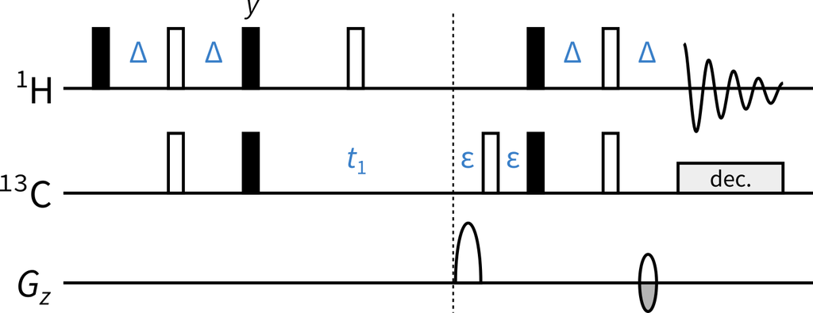

A standard HSQC sequence.

So, (ideally) you should know some of the following:

- Filled bars indicate 90° pulses, and empty bars indicate 180° pulses. (This isn’t a universal convention, but we will use it here.)
- Pulses can be applied on different nuclei, which the left-hand side labels (e.g. $\ce{^1H}$) indicate.
- Empty spaces between pulses represent delays where nothing is done. The duration of each delay is indicated as some symbol.
- The $G_z$ row contains pulsed field gradients.
- The squiggly bit at the end indicates acquisition of an FID.
- Decoupling is applied during the FID.

If you have seen *all* of these, that’s perfect!

If you have at least seen *some* of these, chances are you can read on, as we will briefly introduce each component as we go along.

If you have *never* seen this kind of diagram before, then I suggest reading an introductory NMR book. I personally recommend James Keeler’s [*Understanding NMR Spectroscopy*, 2nd ed](https://www.amazon.co.uk/Understanding-NMR-Spectroscopy-James-Keeler/dp/0470746084). If you can’t find this at a library, there are PDFs of an older version which can be downloaded from [here](http://www-keeler.ch.cam.ac.uk/lectures/).

For the entire series of posts, you will likely need to read up to the chapter on pulsed field gradients, although the chapter on relaxation can be skipped. It may seem like a lot, but my opinion is that at *some point in time* you will probably need to read it anyway, so you may as well start off with some good foundations.

For a *very* brief overview, or a refresher, the first chapter of Tim Claridge’s [*High-Resolution NMR Techniques in Organic Chemistry*, 3rd ed.](https://www.amazon.co.uk/High-Resolution-NMR-Techniques-Organic-Chemistry/dp/0080999867), or the last chapter of Peter Hore’s [*Nuclear Magnetic Resonance*, 2nd ed.](https://www.amazon.co.uk/Nuclear-Magnetic-Resonance-Chemistry-Primers/dp/0198703414/) will suffice.